# Variable time step ODE solver

[AMath 586, Spring Quarter 2019](http://staff.washington.edu/rjl/classes/am586s2019/) at the University of Washington. For other notebooks, see Index.html or the [Index of all notebooks on Github](https://github.com/rjleveque/amath586s2019/blob/master/notebooks/Index.html).

This notebook gives a simplified implementation of a variable time step ODE solver based on an order 1,2 embedded Runge-Kutta method given by (5.42) in [the textbook](http://staff.washington.edu/rjl/fdmbook/).

```python
%matplotlib inline
```

```python
from pylab import *
```

Solve the ODE

$$ u'(t) = \lambda(u - g(t)) + g'(t), \qquad u(0) = \eta $$

where $g(t)$ is a given function. The exact solution is

$$u(t) = \exp(\lambda t)(\eta - g(0)) + g(t).$$

In ScalarStiffness.html we used $g(t) = \cos(t)$, but here we modify this function $g(t)$ to also include a sharply peaked Gaussian $\exp(-\gamma (t-1)^2)$ where small time steps are needed to resolve the solution. We can also choose $\lambda$ very negative to make the problem stiff, or take $\lambda$ near 0 to make it easier to solve with an explicit method.

```python
gamma = 500.

def g(t):
    return cos(t) + exp(-gamma*(t-1.)**2)

def gprime(t):
    return -sin(t) - 2*gamma*(t-1.)*exp(-gamma*(t-1.)**2)
```

Plot of $g(t)$:

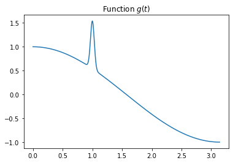

```python
tfine = linspace(0,pi,2000)
plot(tfine, g(tfine))
title('Function $g(t)$');
```

## Implement a variable time step method

This is a simple implementation of the embedded Runge-Kutta method given by (5.42) in the textbook, along with choosing the time step $k_{n+1}$ based on the estimate of the local error in Forward Euler obtained from the previous step,

$$ |{\cal L}^n| \approx \frac 1 2 k_n^2 |u''(t_n)| \approx |\hat U^{n+1} - U^{n+1}|. $$

For a given tolerance $\epsilon$ (called `tol` in the code) and final time $T$ (called `tfinal`), we choose

$$k_{n+1} = \frac{k_n^2 \epsilon}{T |{\cal L}^n|}.$$

Then we hope $|{\cal L}^{n+1}| \leq k_{n+1} \epsilon/T$ and that the local errors accumulate linearly so that the final error at time $T$ satisfies

$$ |E(T)| \leq \sum_{n=0}^{N-1} k_n \epsilon/T = \epsilon, \qquad \text{since}\quad \sum_{n=0}^{N-1} k_n = T. $$

In case $u''(t_n)$ is near zero this might give too large a time step at some times, so also put in a restriction that $k_{n+1} \leq 2k_n$.

```python
def test_variable_dt_method(tol=1e-3, lam=0):
    u0 = 0.

    def f(u,t):
        return lam*(u - g(t)) + gprime(t)

    def utrue(t):
        return exp(lam*(t)) * (u0 - g(0)) + g(t)

    tfinal = 3
    tfine = linspace(0,tfinal,2000)
    ufine = utrue(tfine)  # reference exact solution

    kn = 1e-5 # initial time step
    maxsteps = 1000000 # to avoid infinite loop
    tn = 0.
    Un = u0

    # start accumulating lists (append in each time step)
    times = [tn]
    u = [Un]
    timesteps = [kn]

    for n in range(maxsteps):
        tnp = tn + kn
        F1 = f(Un,tn)
        Y2 = Un + 0.5*kn*F1
        Unp = Un + kn*f(Y2, tn + 0.5*kn)
        Unp_hat = Un + kn*F1

        # Estimate of 1-step error in Euler:
        Ln = abs(Unp_hat - Unp)
        # New time step based on wanting 1-step error <= tol/tfinal:
        knp = kn**2 * tol/(tfinal*Ln)
        # But don't let it grow too fast:
        knp = min(knp, 2*kn)

        #Unp = Unp_hat # to use Euler step rather than 2nd order

        u.append(Unp)
        times.append(tnp)
        timesteps.append(knp)
        Un = Unp
        tn = tnp
        kn = knp

        # check if done:
        if tn > tfinal:
            break

    if (tn < tfinal):
        print('*** Warning, failed to reach tfinal')

    # convert lists into numpy arrays:
    times = array(times)
    u = array(u)
    timesteps = array(timesteps)

    print('Stopping at t=%.3f, after %i timesteps' % (tn, len(u)))
    print('Maximum k = %g,  lambda*(max k) = %g' \
          % (timesteps.max(), lam*timesteps.max()))

    figure(figsize=(11,4))
    subplot(121)
    plot(tfine,ufine,'k')
    plot(times,u)
    title('Solution')
    subplot(122)
    errs = abs(u - utrue(times))
    semilogy([0,tfinal], [tol,tol], 'g--', label='tolerance')
    semilogy(times,errs,'r',label='abs(error)')
    semilogy(times,timesteps,'k',label='timestep')
    grid(True)
    ylim(1e-12, 1)
    legend(loc='lower right')
    title('tol = %g, max error = %g' % (tol,errs.max()));
```

Test on a mild problem with $\lambda = -1$... Try changing `tol` and note that the solution is generally more accurate than requested.

[output not shown]

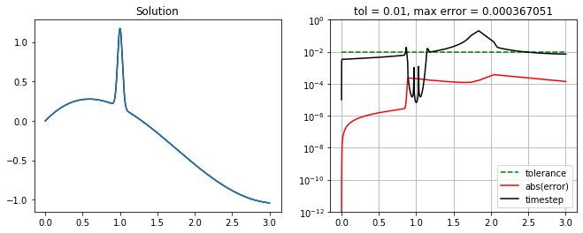

```python
test_variable_dt_method(tol=1e-2, lam=-1)
```

Try a stiffer equation. Note that the time step is automatically adjusted to stay close to the stability region (which intersects the real axis at $k\lambda = -2$):

[output not shown]

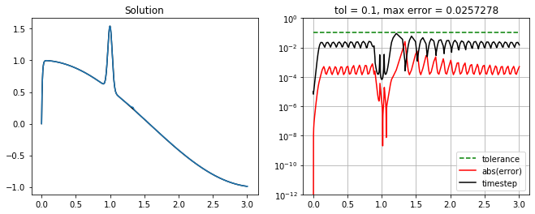

```python
test_variable_dt_method(tol=1e-1, lam=-100)
```